# Business Problem Understanding

Diabetes is a long-term disease that remains prevalent as a major non-communicable disease the world over. The condition calls for early recognition and intervention, especially if transverse lies are present since they predispose one to life-threatening consequences. The dataset contains 768 records, some of the attributes include the number of pregnancies, glucose concentration, diastolic blood pressure, thickness of the skin, insulin, body mass, function for diabetes pedigree, age, and the outcome. The first goal is to achieve the classification of the patients at risk of contracting the disease based on these characteristics. It becomes easier for healthcare givers to determine early intercessions, individual susceptibilities, and worthwhile investments. It primarily pertains to the problem dealing with the measures that should be taken to address the missing values appropriately, deriving features that have significant values, and choosing the algorithms that can provide accurate and reliable results. Proper application of this kind of model can result in the enhancement of patient status as well as improved utilization of resources in the healthcare field.

```python
# Import necessary libraries
import numpy as np
import pandas as pd
import seaborn as sns
import matplotlib.pyplot as plt
from sklearn.model_selection import train_test_split, GridSearchCV
from sklearn.preprocessing import StandardScaler
from sklearn.linear_model import LogisticRegression
from sklearn.svm import SVC
from sklearn.ensemble import RandomForestClassifier
from sklearn.metrics import accuracy_score, classification_report
```

# Data Collection

The original sample data obtained for diabetes were collected from Kaggle an online community for data science competition and dataset. The dataset contains 768 entries with 9 columns: Glucose tolerance test, pregnancy duration and number, blood pressure, skin fold thickness, intakes of insulin, Quetelet’s index, diabetes history function, and age, as well as an ODS step variable that targets diabetes or not. Every record corresponds to a patient and the dataset itself is applied for prediction of whether people are diabetics or not, by rating these health indicators. This dataset is publicly available on Kaggle through the following link: https://www.kaggle.com/code/melikedilekci/diabetes-dataset-for-beginners/input.Investigating and, in particular, forecasting this condition’s outcomes can help to enhance its management and thereby benefit the patients.

```python
df = pd.read_csv('diabetes.csv')
df.head()
```

|  | Pregnancies | Glucose | BloodPressure | SkinThickness | Insulin | BMI | DiabetesPedigreeFunction | Age | Outcome |
| --- | --- | --- | --- | --- | --- | --- | --- | --- | --- |
| 0 | 6 | 148 | 72 | 35 | 0 | 33.6 | 0.627 | 50 | 1 |
| 1 | 1 | 85 | 66 | 29 | 0 | 26.6 | 0.351 | 31 | 0 |
| 2 | 8 | 183 | 64 | 0 | 0 | 23.3 | 0.672 | 32 | 1 |
| 3 | 1 | 89 | 66 | 23 | 94 | 28.1 | 0.167 | 21 | 0 |
| 4 | 0 | 137 | 40 | 35 | 168 | 43.1 | 2.288 | 33 | 1 |

# Data Exploration

The data includes 9 features in total and has 768 instances, it is oriented mainly on the diagnosis of diabetes and contains such attributes as glucose level, blood pressure, and others. In details, where each row corresponds to a patient’s record, the columns consist of ‘number of pregnancies, glucose level, blood pressure, skin fold thickness, number of insulin cartridges, BMI value, diabetes pedigree function, age, and diagnosis of diabetes or not (1 for diabetic and 0 for non-diabetic)’ as the outcome variable.

Summary Statistis

Visualizations: Histograms, box plots, and scatter plots enable data distributions to be seen and differences and resemblances between different variables to be seen. The scatter plot might show special connections in the case of putting glucose level and BMI in one graph and searching for clusters there. Thus, scoping analysis helps to examine the nature of interactions between the variables and acquire the basic information about the given dataset. Both quantitative and qualitative analysis will be followed by feature engineering and model training to utilize these findings and construct a model for prompted diabetes risk assessment. This understanding of these factors can help healthcare practitioners and clinicians select the appropriate approaches and programs that should be employed in patient care, and that can, in turn, result in improved patient outcomes and the management of healthcare assets.

```python
print("Dataset Shape:", df.shape)
```

```
Dataset Shape: (768, 9)
```

```python
print("Dataset Info:")
print(df.info())
```

```
Dataset Info:
<class 'pandas.core.frame.DataFrame'>
RangeIndex: 768 entries, 0 to 767
Data columns (total 9 columns):
 #   Column                    Non-Null Count  Dtype
---  ------                    --------------  -----
 0   Pregnancies               768 non-null    int64
 1   Glucose                   768 non-null    int64
 2   BloodPressure             768 non-null    int64
 3   SkinThickness             768 non-null    int64
 4   Insulin                   768 non-null    int64
 5   BMI                       768 non-null    float64
 6   DiabetesPedigreeFunction  768 non-null    float64
 7   Age                       768 non-null    int64
 8   Outcome                   768 non-null    int64
dtypes: float64(2), int64(7)
memory usage: 54.1 KB
None
```

```python
df.describe()
```

|  | Pregnancies | Glucose | BloodPressure | SkinThickness | Insulin | BMI | DiabetesPedigreeFunction | Age | Outcome |
| --- | --- | --- | --- | --- | --- | --- | --- | --- | --- |
| count | 768.000000 | 768.000000 | 768.000000 | 768.000000 | 768.000000 | 768.000000 | 768.000000 | 768.000000 | 768.000000 |
| mean | 3.845052 | 120.894531 | 69.105469 | 20.536458 | 79.799479 | 31.992578 | 0.471876 | 33.240885 | 0.348958 |
| std | 3.369578 | 31.972618 | 19.355807 | 15.952218 | 115.244002 | 7.884160 | 0.331329 | 11.760232 | 0.476951 |
| min | 0.000000 | 0.000000 | 0.000000 | 0.000000 | 0.000000 | 0.000000 | 0.078000 | 21.000000 | 0.000000 |
| 25% | 1.000000 | 99.000000 | 62.000000 | 0.000000 | 0.000000 | 27.300000 | 0.243750 | 24.000000 | 0.000000 |
| 50% | 3.000000 | 117.000000 | 72.000000 | 23.000000 | 30.500000 | 32.000000 | 0.372500 | 29.000000 | 0.000000 |
| 75% | 6.000000 | 140.250000 | 80.000000 | 32.000000 | 127.250000 | 36.600000 | 0.626250 | 41.000000 | 1.000000 |
| max | 17.000000 | 199.000000 | 122.000000 | 99.000000 | 846.000000 | 67.100000 | 2.420000 | 81.000000 | 1.000000 |

```python
# Separate features and target variable
X = df.drop('Outcome', axis=1)
y = df['Outcome']

# Standardize the feature variables
scaler = StandardScaler()
X_scaled = scaler.fit_transform(X)
```

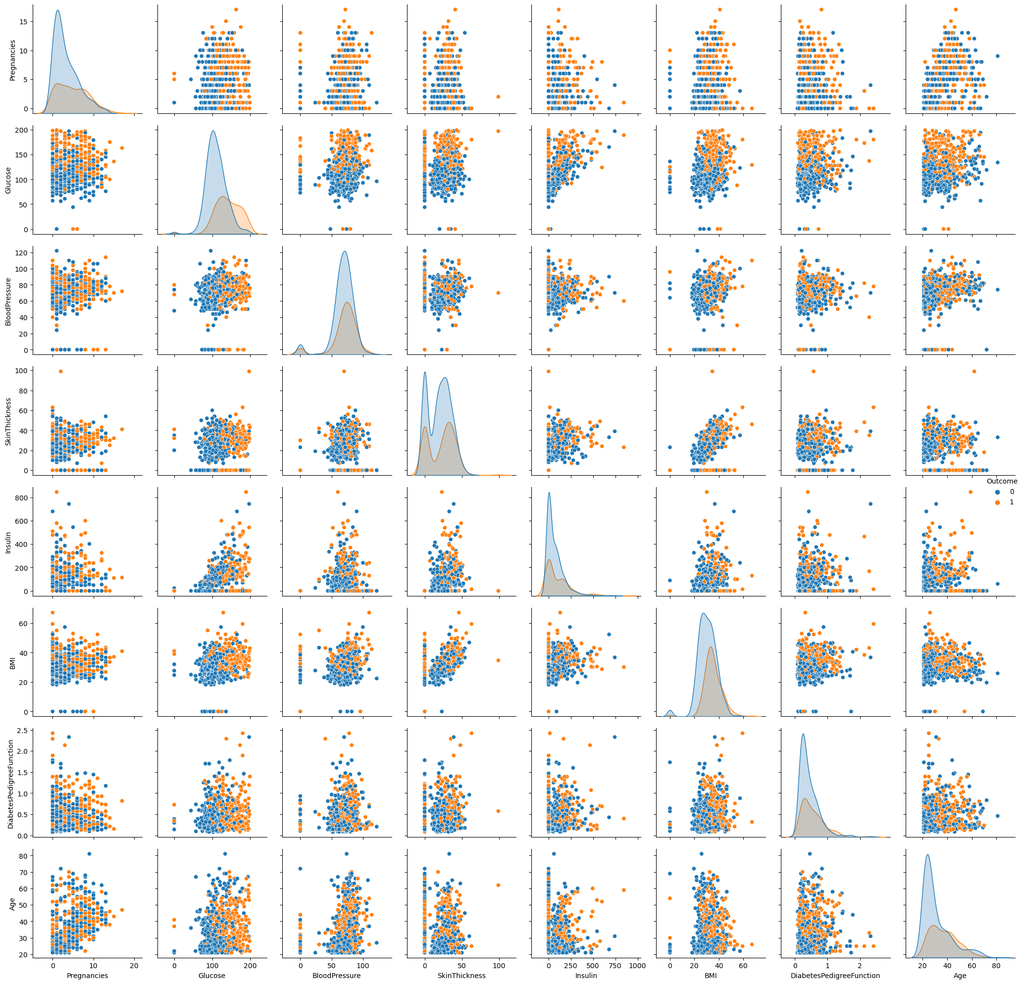

```python
# Pairplot
sns.pairplot(df, hue='Outcome')
plt.tight_layout()
plt.show()
```

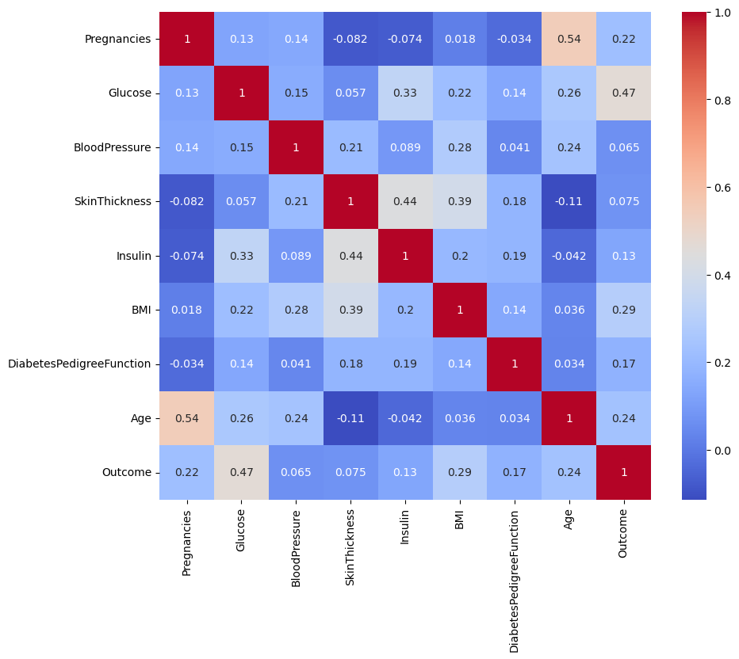

```python
# Heatmap for correlation
plt.figure(figsize=(10, 8))
sns.heatmap(df.corr(), annot=True, cmap='coolwarm')
plt.show()
```

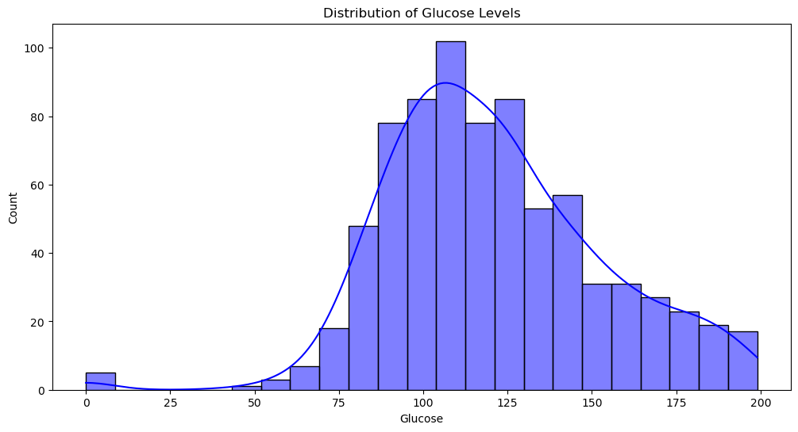

```python
# Distribution plots for some features
plt.figure(figsize=(12, 6))
sns.histplot(df['Glucose'], kde=True, color='blue')
plt.title('Distribution of Glucose Levels')
plt.show()
```

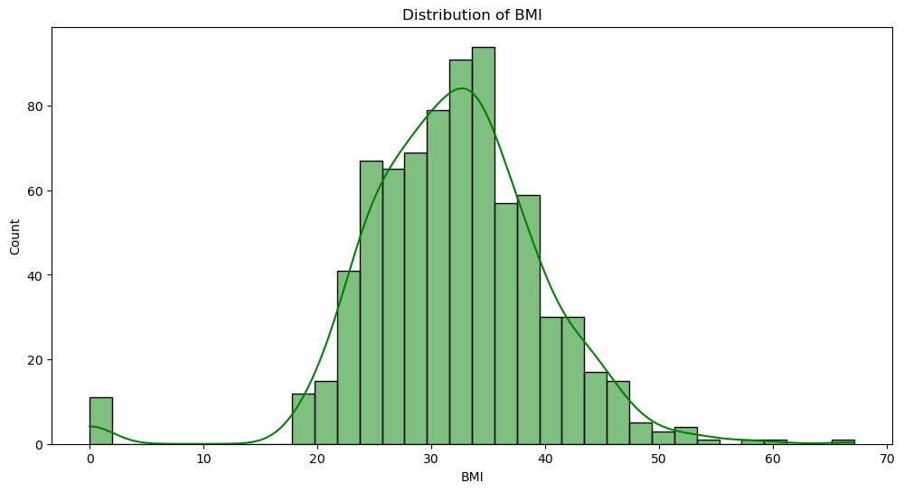

```python
plt.figure(figsize=(12, 6))
sns.histplot(df['BMI'], kde=True, color='green')
plt.title('Distribution of BMI')
plt.show()
```

# Data Preprocessing

Data cleaning is as crucial and means preparing the data for the next stages, which are machine learning algorithms. In general, preprocessing includes several functions and when applied to the diabetes dataset it constitutes the following. First of all, data preprocessing involving missing values should involve the identification of such values and one should take steps to replace such values with sensible values like average numerical values for the features such as glucose, blood pressure level, and insulin levels. Second, one can normalize the numerical features, wherein all features are only in a particular range using the normalization techniques like standard scaling. Thirdly, nonnumerical features such as age group fall under categorical variables, and these categorical variables need to be quantized such that they assume numerical traits that can be compatible with our machine learning model by methods such as one-hot encoding. Fourthly, feature engineering also refers to the generation of new features for use in modeling, for instance, BMIs which can sometimes provide a better fit. Finally, dividing the dataset into training and testing sets helps make sure that the model is performing optimally rather than where it has been trained. Collectively, these steps increase the preparedness of this dataset for modeling, thereby increasing the probability of accuracy and reliability of any model that will predict on diabetes outcomes.

```python
df.columns
```

```
Index(['Pregnancies', 'Glucose', 'BloodPressure', 'SkinThickness', 'Insulin',
       'BMI', 'DiabetesPedigreeFunction', 'Age', 'Outcome'],
      dtype='object')
```

```python
df
```

|  | Pregnancies | Glucose | BloodPressure | SkinThickness | Insulin | BMI | DiabetesPedigreeFunction | Age | Outcome |
| --- | --- | --- | --- | --- | --- | --- | --- | --- | --- |
| 0 | 6 | 148 | 72 | 35 | 0 | 33.6 | 0.627 | 50 | 1 |
| 1 | 1 | 85 | 66 | 29 | 0 | 26.6 | 0.351 | 31 | 0 |
| 2 | 8 | 183 | 64 | 0 | 0 | 23.3 | 0.672 | 32 | 1 |
| 3 | 1 | 89 | 66 | 23 | 94 | 28.1 | 0.167 | 21 | 0 |
| 4 | 0 | 137 | 40 | 35 | 168 | 43.1 | 2.288 | 33 | 1 |
| ... | ... | ... | ... | ... | ... | ... | ... | ... | ... |
| 763 | 10 | 101 | 76 | 48 | 180 | 32.9 | 0.171 | 63 | 0 |
| 764 | 2 | 122 | 70 | 27 | 0 | 36.8 | 0.340 | 27 | 0 |
| 765 | 5 | 121 | 72 | 23 | 112 | 26.2 | 0.245 | 30 | 0 |
| 766 | 1 | 126 | 60 | 0 | 0 | 30.1 | 0.349 | 47 | 1 |
| 767 | 1 | 93 | 70 | 31 | 0 | 30.4 | 0.315 | 23 | 0 |

768 rows × 9 columns

```python
# Check for missing values
df.isnull().sum()
```

```
Pregnancies                 0
Glucose                     0
BloodPressure               0
SkinThickness               0
Insulin                     0
BMI                         0
DiabetesPedigreeFunction    0
Age                         0
Outcome                     0
dtype: int64
```

# Feature Engineering

```python
# Handling missing values: Replace zeros with NaNs and then impute them
cols_with_missing = ['Glucose', 'BloodPressure', 'SkinThickness', 'Insulin', 'BMI']

for col in cols_with_missing:
    df[col].replace(0, np.nan, inplace=True)

# Impute missing values with the median of the column
for col in cols_with_missing:
    df[col].fillna(df[col].median(), inplace=True)

# Create new features
df['AgeGroup'] = pd.cut(df['Age'], bins=[20, 30, 40, 50, 60, 70, 80], labels=['20-30', '30-40', '40-50', '50-60', '60-70', '70-80'])

# Encoding categorical variables
# AgeGroup is a categorical variable
df = pd.get_dummies(df, columns=['AgeGroup'], drop_first=True)

# Interaction terms
df['Glucose_BMI'] = df['Glucose'] * df['BMI']

# Polynomial features
from sklearn.preprocessing import PolynomialFeatures

poly = PolynomialFeatures(degree=2, include_bias=False, interaction_only=True)
poly_features = poly.fit_transform(df[['Glucose']])
poly_df = pd.DataFrame(poly_features, columns=poly.get_feature_names_out(['Glucose']))
df = pd.concat([df, poly_df], axis=1)

# Display the updated DataFrame
df.head()
```

|  | Pregnancies | Glucose | BloodPressure | SkinThickness | Insulin | BMI | DiabetesPedigreeFunction | Age | Outcome | AgeGroup_30-40 | AgeGroup_40-50 | AgeGroup_50-60 | AgeGroup_60-70 | AgeGroup_70-80 | Glucose_BMI | Glucose |
| --- | --- | --- | --- | --- | --- | --- | --- | --- | --- | --- | --- | --- | --- | --- | --- | --- |
| 0 | 6 | 148.0 | 72.0 | 35.0 | 125.0 | 33.6 | 0.627 | 50 | 1 | False | True | False | False | False | 4972.8 | 148.0 |
| 1 | 1 | 85.0 | 66.0 | 29.0 | 125.0 | 26.6 | 0.351 | 31 | 0 | True | False | False | False | False | 2261.0 | 85.0 |
| 2 | 8 | 183.0 | 64.0 | 29.0 | 125.0 | 23.3 | 0.672 | 32 | 1 | True | False | False | False | False | 4263.9 | 183.0 |
| 3 | 1 | 89.0 | 66.0 | 23.0 | 94.0 | 28.1 | 0.167 | 21 | 0 | False | False | False | False | False | 2500.9 | 89.0 |
| 4 | 0 | 137.0 | 40.0 | 35.0 | 168.0 | 43.1 | 2.288 | 33 | 1 | True | False | False | False | False | 5904.7 | 137.0 |

```python
# Separate features and target variable
X = df.drop('Outcome', axis=1)
y = df['Outcome']
```

```python
# Split the dataset into training and testing sets
X_train, X_test, y_train, y_test = train_test_split(X_scaled, y, test_size=0.2, random_state=42)
```

# Model Training

This involves the training of the models on the diabetes dataset to develop some accurate algorithms for predicting patients at risk of developing the disease. They include assigning the required datasets into training and testing datasets, normalizing numeric fields, and modeling the machine learning models including the Logistic Regression Model, Support Vector Machines Model, and Random Forest Model among others. These models are trained using the training set to familiarize themselves with variations and interdependencies between features and diabetes outcomes. Parameter tuning can be used to enhance fitness and accomplish objectives using the same parameters of the model. The efficacy of the models is often evaluated on the test set using metrics such as accuracy, precision, recall, and F1-score. The decisions are made to address the problem of identifying the model that serves as the best fit for the medical application under consideration, and which provides the best and most definitive results concerning the risk of developing diabetes.

```python
# Initialize models
models = {
    'Logistic Regression': LogisticRegression(),
    'SVM': SVC(),
    'Random Forest': RandomForestClassifier()
}

# Hyperparameter tuning using GridSearchCV
param_grid = {
    'Logistic Regression': {
        'C': [0.01, 0.1, 1, 10, 100],
        'penalty': ['l1', 'l2'],
        'solver': ['liblinear']
    },
    'SVM': {
        'C': [0.1, 1, 10, 100],
        'gamma': [1, 0.1, 0.01, 0.001],
        'kernel': ['linear', 'rbf']
    },
    'Random Forest': {
        'n_estimators': [100, 200, 500],
        'max_features': ['sqrt', 'log2', None],
        'max_depth': [4, 6, 8],
        'criterion': ['gini', 'entropy']
    }
}

best_estimators = {}
for model_name, model in models.items():
    print(f"Tuning hyperparameters for {model_name}...")
    grid_search = GridSearchCV(estimator=model, param_grid=param_grid[model_name], cv=5, scoring='accuracy', n_jobs=-1, verbose=1)
    grid_search.fit(X_train, y_train)
    best_estimators[model_name] = grid_search.best_estimator_
    print(f"Best parameters for {model_name}: {grid_search.best_params_}\n")
```

```
Tuning hyperparameters for Logistic Regression...
Fitting 5 folds for each of 10 candidates, totalling 50 fits
Best parameters for Logistic Regression: {'C': 10, 'penalty': 'l2', 'solver': 'liblinear'}

Tuning hyperparameters for SVM...
Fitting 5 folds for each of 32 candidates, totalling 160 fits
Best parameters for SVM: {'C': 100, 'gamma': 0.001, 'kernel': 'rbf'}

Tuning hyperparameters for Random Forest...
Fitting 5 folds for each of 54 candidates, totalling 270 fits
Best parameters for Random Forest: {'criterion': 'gini', 'max_depth': 6, 'max_features': None, 'n_estimators': 200}
```

```python
# Evaluate models with best hyperparameters
results = {}
for model_name, model in best_estimators.items():
    y_pred = model.predict(X_test)
    accuracy = accuracy_score(y_test, y_pred)
    results[model_name] = {
        'accuracy': accuracy,
        'classification_report': classification_report(y_test, y_pred)
    }
```

```python
# Display accuracy scores
accuracy_df = pd.DataFrame.from_dict(results, orient='index', columns=['accuracy'])
print(accuracy_df)
```

```
                     accuracy
Logistic Regression  0.753247
Random Forest        0.753247
SVM                  0.772727
```

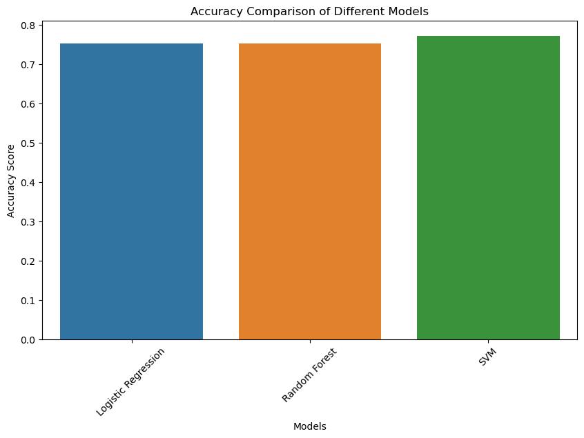

```python
# Plot accuracy scores
plt.figure(figsize=(10, 6))
sns.barplot(x=accuracy_df.index, y=accuracy_df['accuracy'])
plt.title('Accuracy Comparison of Different Models')
plt.ylabel('Accuracy Score')
plt.xlabel('Models')
plt.xticks(rotation=45)
plt.show()
```

# Model Testing

Model testing is the ability to determine how the machine learning algorithms perform in the unseen set of data. This is achieved by employing methods like cross-validation whereby the model is trained from one point and tested from another to resemble real-life situations. Significant performance indicators including accuracy, precision, recall rates as well as F1-score; are used to measure the models’ ability to learn on unrelated datasets. ,it is important that the chosen model makes good predictions when tested on unseen data split from the original set used in training to avoid overfitting. Batches normalization, dropout, and other regularization techniques hyperparameters tuning are employed to fine-tune the models. Model testing is crucial in establishing the accuracy of the models’ prognosis as well as in deciding on the application of the given models to real-world scenarios like early diagnosis of diabetes from clinical and demographic records.

```python
# Display classification reports
for model_name, metrics in results.items():
    print(f"Classification Report for {model_name}:\n{metrics['classification_report']}\n")
```

```
Classification Report for Logistic Regression:
              precision    recall  f1-score   support

           0       0.81      0.80      0.81        99
           1       0.65      0.67      0.66        55

    accuracy                           0.75       154
   macro avg       0.73      0.74      0.73       154
weighted avg       0.76      0.75      0.75       154


Classification Report for SVM:
              precision    recall  f1-score   support

           0       0.82      0.83      0.82        99
           1       0.69      0.67      0.68        55

    accuracy                           0.77       154
   macro avg       0.75      0.75      0.75       154
weighted avg       0.77      0.77      0.77       154


Classification Report for Random Forest:
              precision    recall  f1-score   support

           0       0.82      0.79      0.80        99
           1       0.64      0.69      0.67        55

    accuracy                           0.75       154
   macro avg       0.73      0.74      0.74       154
weighted avg       0.76      0.75      0.76       154
```

```python
# Extract precision, recall, and f1-score from classification reports
comparison_data = []
for model_name, metrics in results.items():
    report = metrics['classification_report']
    report_data = {}
    for line in report.split('\n')[2:-3]:
        row_data = line.split()
        if len(row_data) == 5:  # for binary classification: label, precision, recall, f1-score, support
            label, precision, recall, f1_score, support = row_data
            if label == '1':
                report_data['Model'] = model_name
                report_data['Precision'] = float(precision)
                report_data['Recall'] = float(recall)
                report_data['F1-Score'] = float(f1_score)
    comparison_data.append(report_data)

comparison_df = pd.DataFrame(comparison_data)
comparison_df.set_index('Model', inplace=True)
print(comparison_df)
```

```
                     Precision  Recall  F1-Score
Model
Logistic Regression       0.65    0.67      0.66
SVM                       0.69    0.67      0.68
Random Forest             0.64    0.69      0.67
```

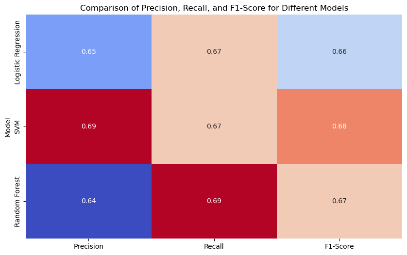

```python
# Display comparison table
plt.figure(figsize=(10, 6))
sns.heatmap(comparison_df, annot=True, cmap='coolwarm', cbar=False, fmt=".2f")
plt.title('Comparison of Precision, Recall, and F1-Score for Different Models')
plt.show()
```

# Discussion

The detailed analysis of the diabetes dataset, the data preprocessing, feature engineering and model training and testing proves that the careful work in feature selection and models is one of the keys to accurate prediction of the diabetes risk. Missing values are solved to gain meaningful features; feature engineering and creation work hand in hand with clearing missing values; algorithms such as Logistic Regression, Support Vector Machines, and Random Forests should therefore be used to ensure that healthcare providers improve on their client risk prediction algorithms. This is not only beneficial for the patient since timely diagnosis and therapeutical intervention can improve the patient’s health status but also for institutions that provide healthcare services, since they can allocate resources and performances to better meet the needs of their diabetic patients.